# DSCI353-353m-453: Class 04a GGplot Graphics in Action

Profs: R. H. French, L. S. Bruckman, P. Leu, K. Davis, S. Cirlos

TAs: W. Oltjen, K. Hernandez, M. Li, M. Li, D. Colvin

07 February, 2023

#### `ggplot2` Graphics

- A good book on `ggplot2` is The Grammar of Graphics

#### Creating a graph with ggplot

- The `ggplot2` package uses a series of functions
  - to build up a graph in layers.
- We’ll build a complex graph
  - by starting with a simple graph
  - and adding additional elements, one at a time.
- By default, `ggplot2` graphs
  - appear on a grey background
  - with white reference lines.
- We’ll start by setting the default theme
  - to a white background
  - with light grey reference lines.
- This looks better when printed in black and white.

Let’s load the `ggplot2` package and set this default theme.

```r
library(ggplot2)
theme_set(theme_bw())
```

- The first function in building a graph is the `ggplot()` function.
- It specifies the
  - data frame containing the data to be plotted
  - the mapping of the variables to visual properties of the graph.

The mappings are placed in an `aes()` function

- (which stands for aesthetics or “something you can see”).

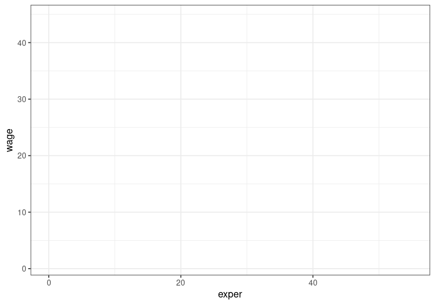

```r
library(ggplot2)
library(mosaicData)
ggplot(data = CPS85, mapping = aes(x = exper, y = wage))
```

Why is the graph empty?

- We specified that the exper variable
  - should be mapped to the x-axis
- and that the wage variable
  - should be mapped to the y-axis,
- but we haven’t yet specified what we wanted placed on the graph.

In this case,

- we’ll want points to represent each participant.

##### Geoms

Geoms are the geometric objects

- (points, lines, bars, and shaded regions)
  - that can be placed on a graph.
- They are added using functions that start with the phrase `geom_`.
- Currently, 37 different `geoms` are available and the list is growing.

Table 4.1 describes the more common `geoms`,

- along with frequently used options for each.

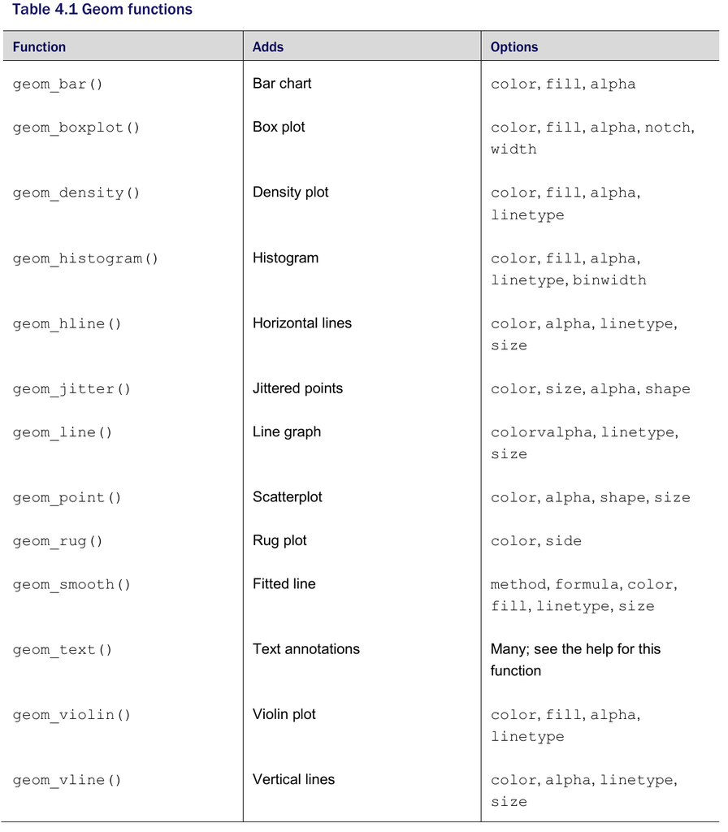

We’ll add points using the `geom_point()` function,

- creating a scatterplot.

In `ggplot2` graphs, functions are chained together

- using the `+` sign to build a final plot.

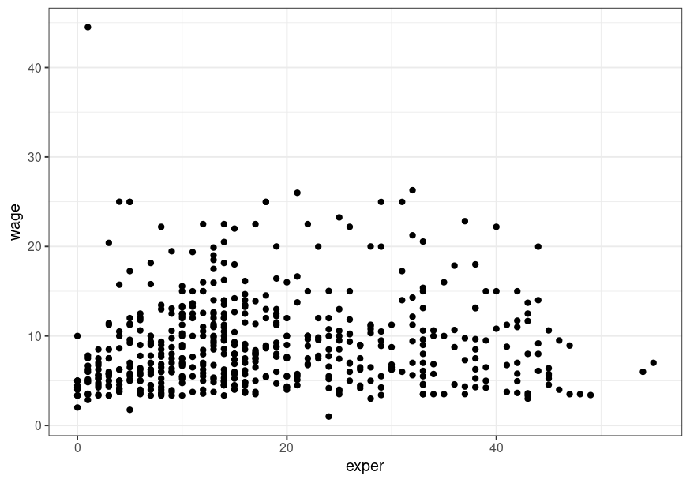

```r
library(ggplot2)
library(mosaicData)
ggplot(data = CPS85, mapping = aes(x = exper, y = wage)) + geom_point()
```

It appears that as experience goes up,

- wages go up,
- but the relationship is weak.

The graph also indicates

- that there is an outlier.
- One individual has a wage
  - much higher than the rest.
- We’ll delete this case and reproduce the plot.

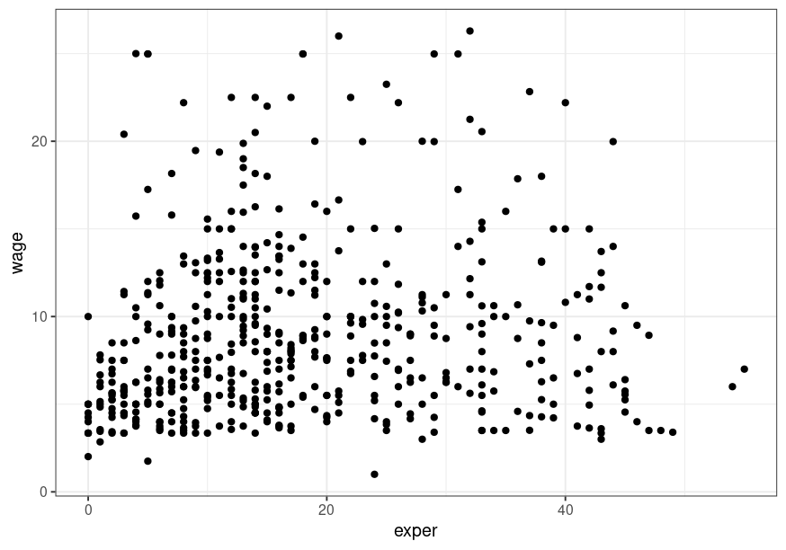

```r
CPS85 <- CPS85[CPS85$wage < 40, ]
ggplot(data = CPS85, mapping = aes(x = exper, y = wage)) +
  geom_point()
```

A number of options can be specified

- in a `geom_` function (see table 4.1).
- Options for `geom_point()`
  - include `color`, `size`, `shape`, and `alpha`.
- These control
  - the point color, size, shape, and transparency, respectively.
- Colors can be specified by name or hexadecimal code.
- Shape and linetype can be specified by
  - the name or number representing the pattern or symbol respectively.
- Point size is specified with positive real numbers starting at zero.
- Large numbers produce larger point sizes.
- Transparency (`alpha`) ranges from
  - 0 (completely transparent)
  - to 1 (completely opaque).
- Adding a degree of transparency
  - can help visualize overlapping points.

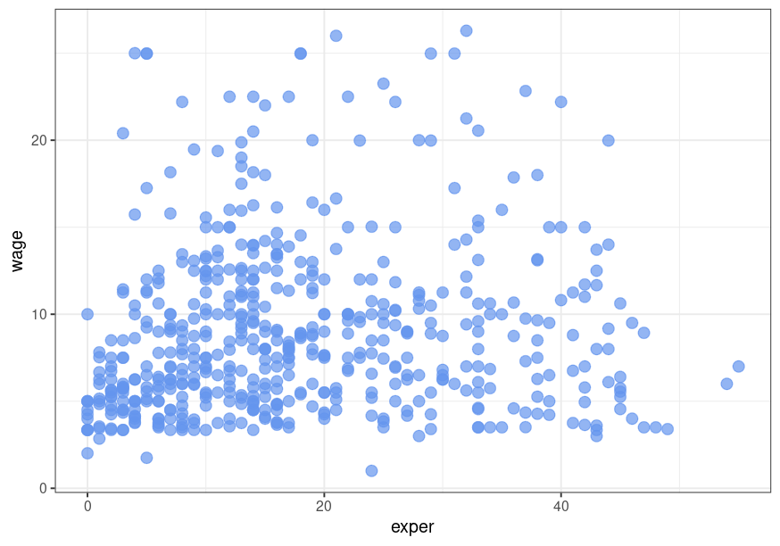

```r
ggplot(data = CPS85, mapping = aes(x = exper, y = wage)) +
  geom_point(color = "cornflowerblue",
             alpha = .7,
             size = 3)
```

It would be helpful if the graph

- had a line summarizing the trend between experience and wages.

We can add this line with the `geom_smooth()` function.

- Options control the type of line
  - (linear, quadratic, nonparametric),
- the thickness of the line,
- the line’s color,
- and the presence or absence of a confidence interval.

Here we request a linear regression (`method = lm`) line.

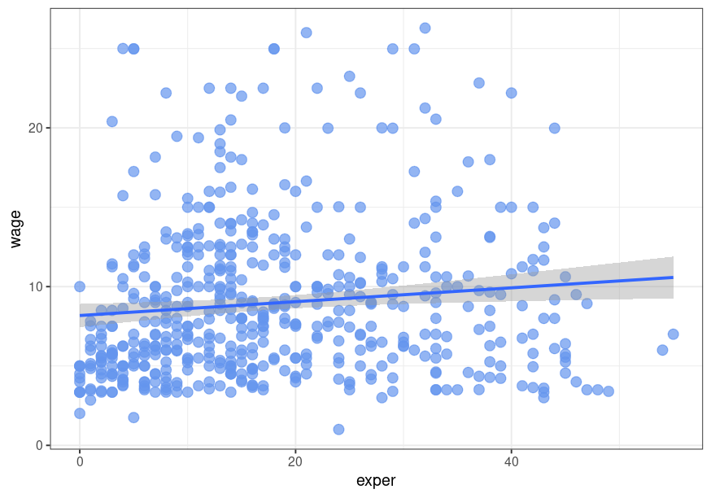

```r
ggplot(data = CPS85, mapping = aes(x = exper, y = wage)) +
  geom_point(color = "cornflowerblue",
             alpha = .7,
             size = 3) +
  geom_smooth(method = "lm")
```

We can see from this line that on average,

- wages appear to increase to a moderate degree with experience.

##### Grouping

- In the previous section, we set graph characteristics
  - such as color and transparency to a constant value.
- However, we can also map variables values
  - to the color, shape, size, transparency, line style,
  - and other visual characteristics of geometric objects.
- This allows groups of observations
  - to be superimposed in a single graph
  - (a process called grouping).

Let’s add sex to the plot

- and represent it by color, shape, and linetype.

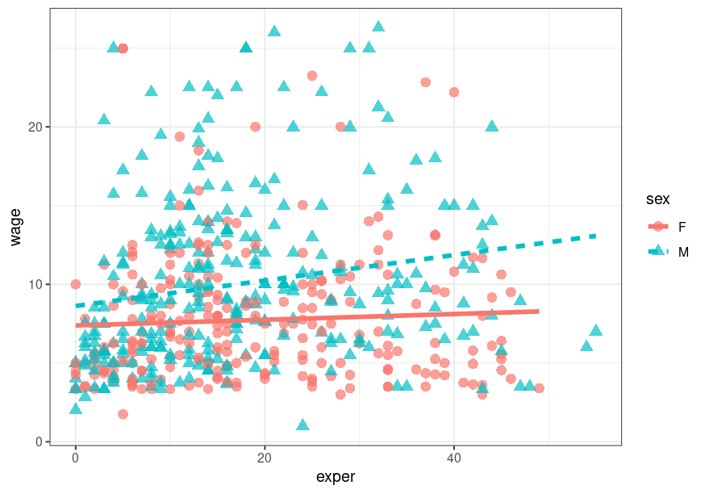

```r
ggplot2::ggplot(
  data = CPS85,
  mapping = aes(
    x = exper,
    y = wage,
    color = sex,
    shape = sex,
    linetype = sex
  )
) +
  geom_point(alpha = .7, size = 3) +
  geom_smooth(method = "lm", se = FALSE, size = 1.5)
```

By default, the first group (female) is represented

- by pink filled circles
  - and a solid pink line,
- while the second group (male) is represented
  - by teal filled triangles
  - and a dashed teal line.

Note that the `color = sex`, `shape = sex`, and `linetype = sex`, options

- are placed in the `aes()` function
  - because we are mapping a variable to an aesthetic.
- The geom_smooth option (`se = FALSE`)
  - was added to suppresses the confidence intervals,
  - making the graph less busy and easier to read.
- The size = 1.5 option
  - makes the line a bit thicker.

##### Scales

As we’ve seen, the `aes()` function is used

- to map variables to the visual characteristics of a plot.
- Scales specify how each of these mappings occurs.
- For example, `ggplot2` automatically creates plot axes
  - with tick marks, tick mark labels, and axis labels.
- Often they look fine, but occasionally
  - you’ll want to take greater control over their appearance.
- Colors that represent groups are chosen automatically,
  - but you may want to select a different set of colors
  - based on your tastes or a publication’s requirements.

Scale functions (which start with `scale_`)

- allow you to modify these default scaling.

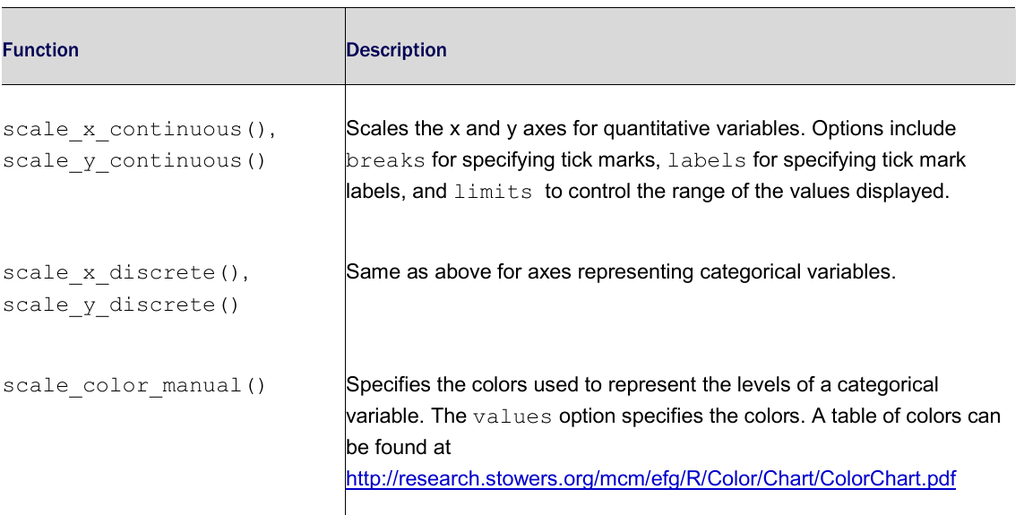

Scales

In the next plot,

- we’ll change the x- and y-axis scaling,
  - and the colors representing males and females.
- The x-axis representing `exper`
  - will range from 0 to 60 by 10,
- and the y-axis representing `wage`
  - will range from 0 to 30 by 5.
- Females will be coded with an off-red color
  - and males will be coded with an off-blue color.

The code

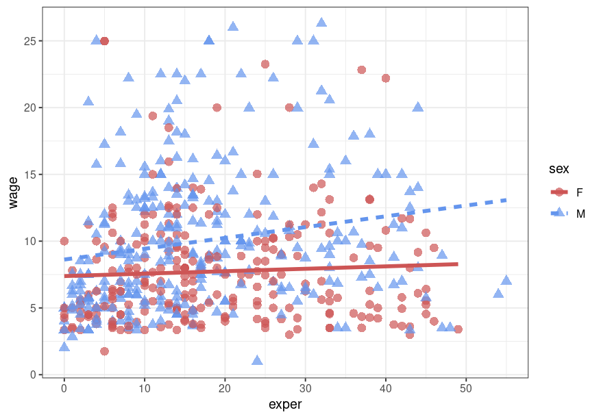

```r
ggplot(data = CPS85,
  mapping = aes(x = exper, y = wage,
  color = sex, shape=sex, linetype=sex)) +
  geom_point(alpha = .7, size = 3) +
  geom_smooth(method = "lm", se = FALSE, size = 1.5) +
  scale_x_continuous(breaks = seq(0, 60, 10)) +
  scale_y_continuous(breaks = seq(0, 30, 5)) +
  scale_color_manual(values = c("indianred3", "cornflowerblue"))
```

Code Styling, using Rstudio’s `Cntrl-Shft-A` to reformat the code.

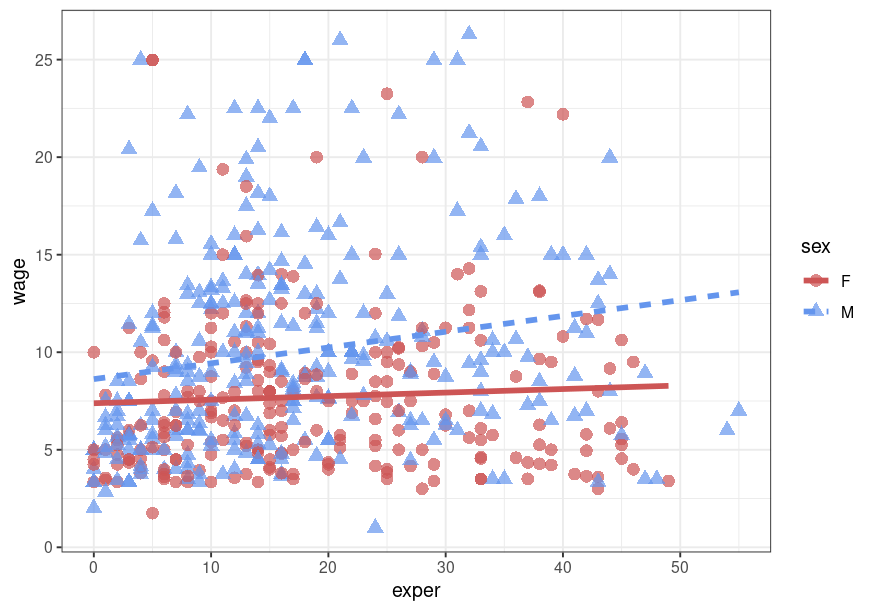

```r
ggplot(
  data = CPS85,
  mapping = aes(
    x = exper,
    y = wage,
    color = sex,
    shape = sex,
    linetype = sex
  )
) +
  geom_point(alpha = .7, size = 3) +
  geom_smooth(method = "lm", se = FALSE, size = 1.5) +
  scale_x_continuous(breaks = seq(0, 60, 10)) +
  scale_y_continuous(breaks = seq(0, 30, 5)) +
  scale_color_manual(values = c("indianred3", "cornflowerblue"))
```

The numbers on the x- and y-axes are better,

- and the colors are more attractive.
- However,
  - wages are in dollars.
- We can change the labels on the y-axis
  - to represent dollars using the `scales` package.
- The scales package provides
  - label formatting for dollars, euros, percents, and more.

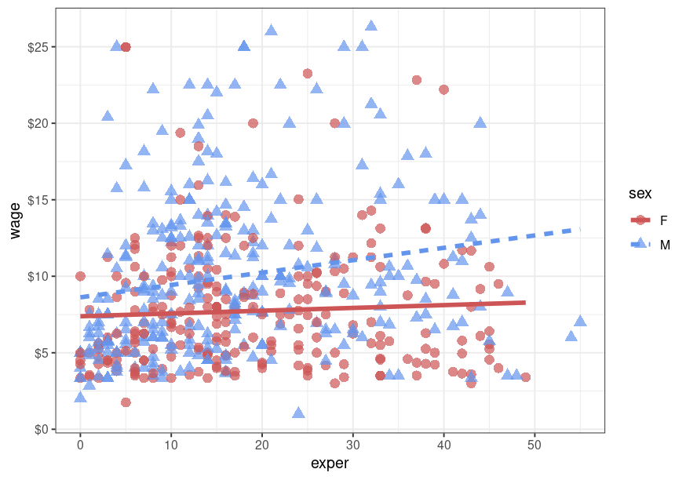

```r
ggplot(
  data = CPS85,
  mapping = aes(
    x = exper,
    y = wage,
    color = sex,
    shape = sex,
    linetype = sex
  )
) +
  geom_point(alpha = .7, size = 3) +
  geom_smooth(method = "lm", se = FALSE, size = 1.5) +
  scale_x_continuous(breaks = seq(0, 60, 10)) +
  scale_y_continuous(breaks = seq(0, 30, 5),
                     label = scales::dollar) +
  scale_color_manual(values = c("indianred3", "cornflowerblue"))
```

We are definitely getting there.

##### Facets

- Here is the next question.
- Is the relationship between
  - `experience`, `wages` and `sex`
  - the same for each job sector?
- Let’s repeat this graph once
  - for each job sector in order to explore this.

Sometimes relationships are clearer

- if groups appear in side-by-side graphs
  - rather than overlapping in a single graph.
- Facets reproduce a graph
  - for each level of a given variable
    - (or combination of variables).
- You can create faceted graphs
  - using the `facet_wrap()` and `facet_grid()` functions.

The syntax is given in table 14.3,

- where `var`, `rowvar`, and `colvar` are factors.

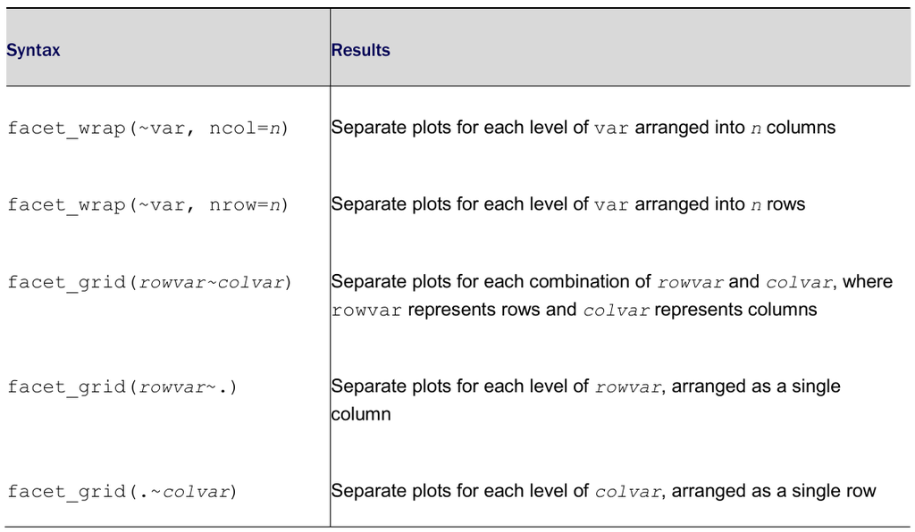

Here, facets will be defined

- by the eight levels of the sector variable.
- Since each facet
  - will be smaller than a one panel graph alone,
- we’ll omit `size = 3` from `geom_point()`
  - and `size = 1.5` from `geom_smooth()`.
- This will reduce the point and line sizes
  - compared with the previous graphs
  - and looks better in a faceted graph.

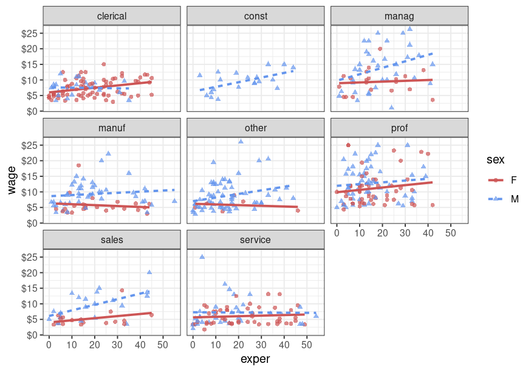

```r
ggplot(
  data = CPS85,
  mapping = aes(
    x = exper,
    y = wage,
    color = sex,
    shape = sex,
    linetype = sex
  )
) +
  geom_point(alpha = .7) +
  geom_smooth(method = "lm", se = FALSE) +
  scale_x_continuous(breaks = seq(0, 60, 10)) +
  scale_y_continuous(breaks = seq(0, 30, 5),
                     label = scales::dollar) +
  scale_color_manual(values = c("indianred3", "cornflowerblue")) +
  facet_wrap( ~ sector)
```

##### Labels

- Graphs should be easy to interpret
  - and informative labels are a key element
  - in achieving this goal.
- The `labs()` function provides customized labels
  - for the axes and legends.
- Additionally, a custom title, subtitle, and caption can be added.

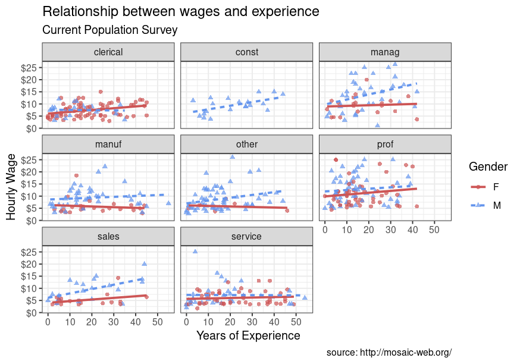

```r
ggplot(
  data = CPS85,
  mapping = aes(
    x = exper,
    y = wage,
    color = sex,
    shape = sex,
    linetype = sex
  )
) +
  geom_point(alpha = .7) +
  geom_smooth(method = "lm", se = FALSE) +
  scale_x_continuous(breaks = seq(0, 60, 10)) +
  scale_y_continuous(breaks = seq(0, 30, 5),
                     label = scales::dollar) +
  scale_color_manual(values = c("indianred3",
                                "cornflowerblue")) +
  facet_wrap( ~ sector) +
  labs(
    title = "Relationship between wages and experience",
    subtitle = "Current Population Survey",
    caption = "source: http://mosaic-web.org/",
    x = " Years of Experience",
    y = "Hourly Wage",
    color = "Gender",
    shape = "Gender",
    linetype = "Gender"
  )
```

Now a viewer doesn’t need to guess

- what the labels `expr` and `wage` mean,
- or where the data come from.

##### Themes

- Finally, we can fine tune the appearance of the graph
  - using themes.
- Theme functions (which start with `theme_`)
  - control background colors, fonts, grid-lines, legend placement,
  - and other non-data related features of the graph.
- Let’s use a cleaner theme.
- We used themes at the beginning in order
  - to give each plot a white background.
- Let’s try a different theme
  - one that is more minimalistic.

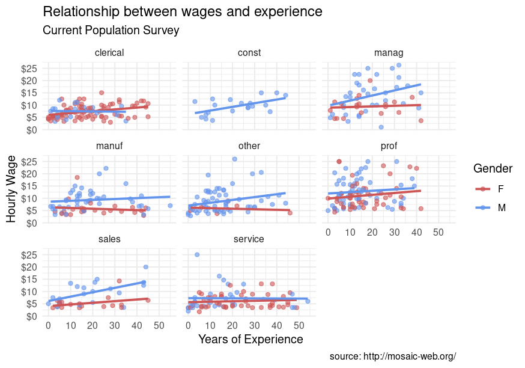

```r
ggplot(data = CPS85,
       mapping = aes(x = exper, y = wage, color = sex)) +
  geom_point(alpha = .6) +
  geom_smooth(method = "lm", se = FALSE) +
  scale_x_continuous(breaks = seq(0, 60, 10)) +
  scale_y_continuous(breaks = seq(0, 30, 5),
                     label = scales::dollar) +
  scale_color_manual(values = c("indianred3", "cornflowerblue")) +
  facet_wrap( ~ sector) +
  labs(
    title = "Relationship between wages and experience",
    subtitle = "Current Population Survey",
    caption = "source: http://mosaic-web.org/",
    x = " Years of Experience",
    y = "Hourly Wage",
    color = "Gender"
  ) +
  theme_minimal()
```

This is our finished graph,

- ready for publication.
- Of course, these findings are tentative.
- They are based on a limited sample size and
  - don’t involve statistical testing
  - to assess whether differences may be due to chance variation.

#### `ggplot2` details

- Before we finish, there are three important topics to consider:
  - the placement of the `aes()` function,
  - the treatment of `ggplot2` graphs as R objects,
  - and various methods to save your graphs
    - for use in reports and webpages.

##### Placing the data and mapping options

- Plots created with `ggplot2`
  - always start with the `ggplot` function.
- In the previous examples,
  - the data= and mapping= options were placed in this function.
- In this case they apply to each geom function that follows.

You can also place these options

- directly within a geom.
- In that case, they only apply to that specific geom.

Consider the following graph.

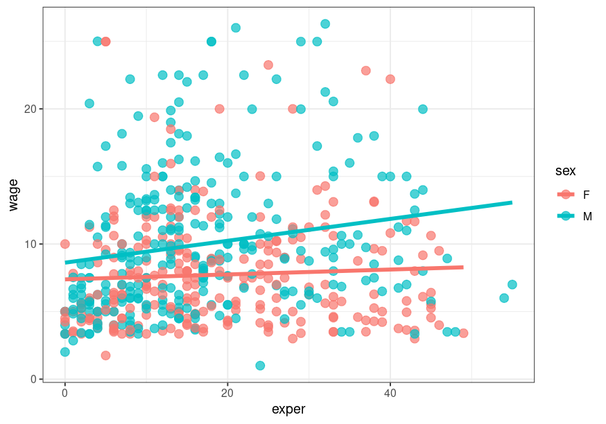

```r
ggplot(CPS85,
       mapping = aes(x = exper, y = wage, color = sex)) +
  geom_point(alpha = .7, size = 3) +
  geom_smooth(method = "lm", se = FALSE, size = 1.5)
```

Since the mapping of sex to color

- appears in the `ggplot()` function,
  - it applies to both `geom_point` and `geom_smooth`.
- The color of the point indicates the sex,
  - and a separate colored trend line is produced for men and women.

Compare this to

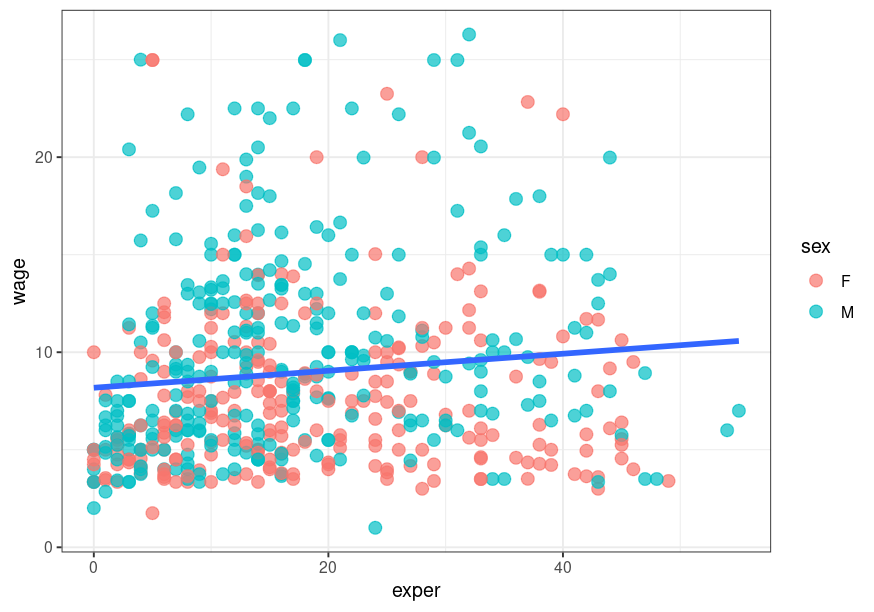

```r
ggplot(CPS85, aes(x = exper, y = wage)) +
  geom_point(aes(color = sex), alpha = .7, size = 3) +
  geom_smooth(method = "lm", se = FALSE, size = 1.5)
```

Since the sex to color mapping

- only appears in the `geom_point()` function,
  - it is only used there.
- A single trend line is created for all observations.

Most examples place the data and mapping options

- in the `ggplot` function.
- Additionally, the phrases `data =` and `mapping =` are omitted
  - since the first option always refers to data
  - and the second option always refers to mapping.

But your code will be more readable and understandable

- If you put the `data =` and `mapping =` - in your code explicitly.

##### Graphs as objects

- A `ggplot2` graph can be saved as
  - a named R object (a list),
- or manipulated further,
  - and then printed or saved to disk.

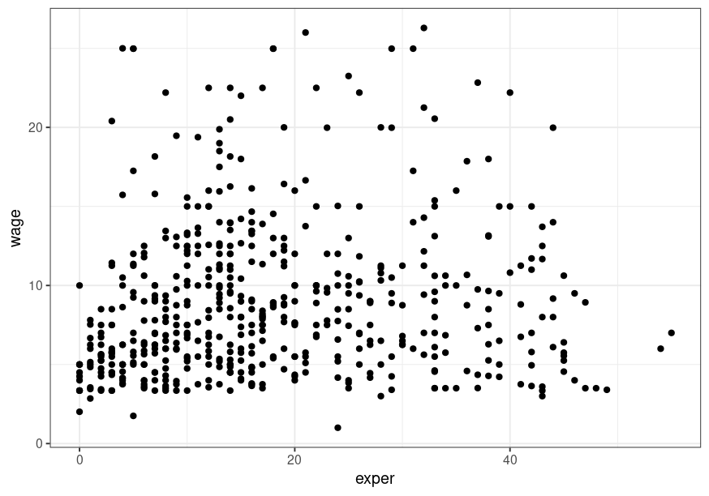

```r
data(CPS85 , package = "mosaicData")      #A
CPS85 <- CPS85[CPS85$wage < 40,]      #A

myplot <- ggplot(data = CPS85, aes(x = exper, y = wage)) + geom_point()     #B

myplot      #C
```

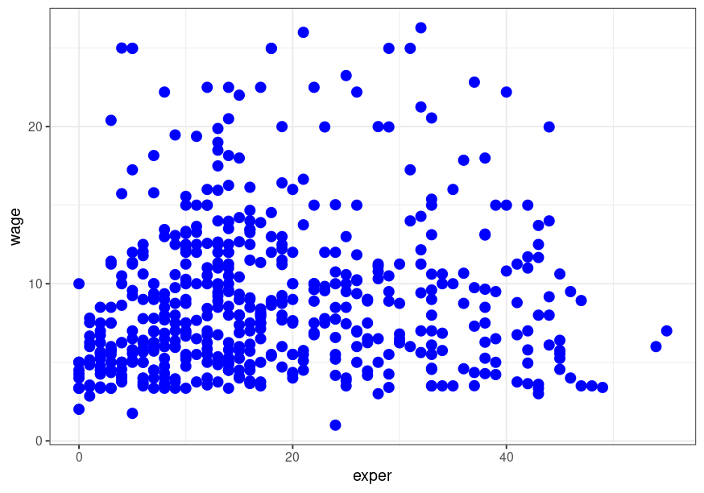

```r
myplot2 <- myplot + geom_point(size = 3, color = "blue")     #D
myplot2      #D
```

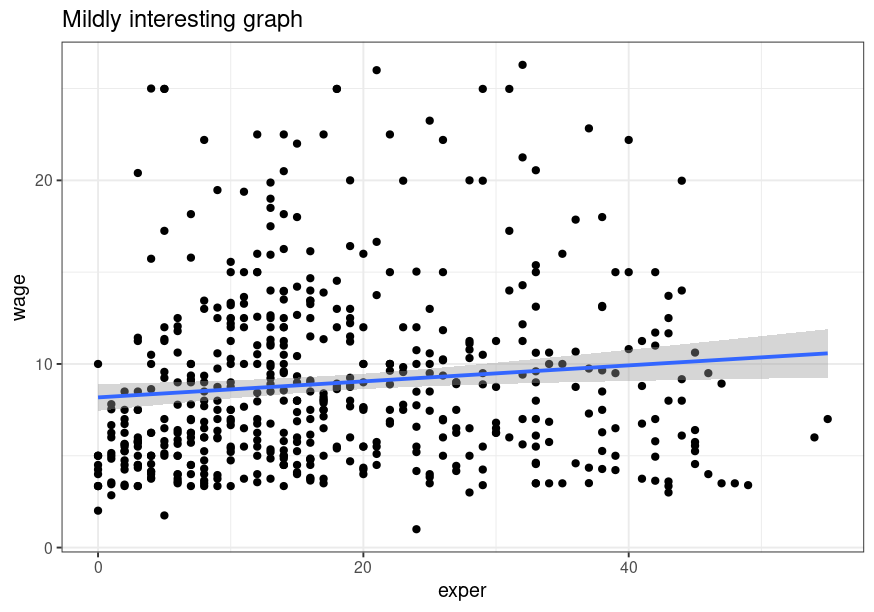

```r
myplot + geom_smooth(method = "lm") +      #E
  labs(title = "Mildly interesting graph")     #E
```

And here is what the codes doing at each letter step

- #A Prepare data
- #B Create a scatterplot and save it as myplot
- #C Display myplot
- #D Make the points larger and blue,
  - save it as myplot2 and display the graph
- #E Display myplot with a best fit line and a title

First the data are imported and outliers are removed #A.

- Then a simple scatter plot of experience vs. wages
  - is created and saved as myplot #B.
- Next, the plot is printed #C.
- The plot is then modified
  - by changing the point size and color,
  - saved as myplot2 and printed #D.
- Finally, the original plot
  - is given a line of best fit and title, and printed #E.

Note that these changes are not saved.

The ability to save graphs as objects

- allows you to continue to work with and modify them.
- This can be a real time saver (and help you avoid carpal tunnel syndrome).
- It is also handy when saving graphs programmatically.

##### Exporting graphs

- You can export graphs created by `ggplot2`
  - in a variety of image formats
  - using the RStudio GUI
  - or through your code.
- To export a graph using the RStudio menus,
  - go to the Plots tab and choose Export

To export a graph via code

- use the `ggsave()` function.
- You can specify the plot to save,
  - its size and format,
  - and where to save it. For example,
  - `ggsave(file = "mygraph.png", plot = myplot, width = 5, height = 4)`
  - saves myplot as a 5-inch by 4-inch PNG file
  - named mygraph.png
  - in the current working directory.

You can save the graph in a different format

- by changing the file extension.

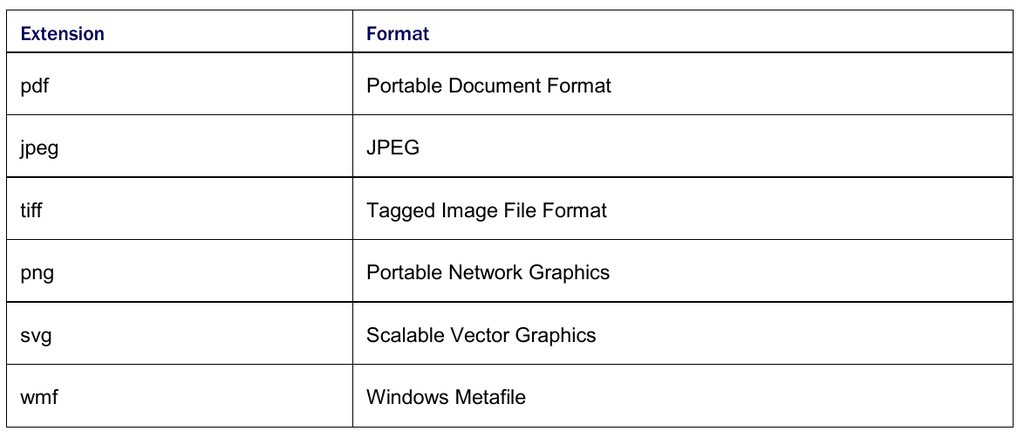

Image File Formats

The pdf, svg, and wmf formats are lossless

- they resize without fuzziness or pixilation.
- The other formats are lossy
  - they will pixelate when resized.
  - This is especially noticeable when small images are enlarged.
- The png format is popular for images destined for webpages.
- The jpeg and tif formats are usually reserved for photographs.

The `wmf` format is usually recommended for graphs

- that will appear in Microsoft Word or PowerPoint documents.
- MS Office does not support `pdf` or `svg` files,
  - and the `wmf` format will rescale well.
- However, note that `wmf` files
  - will lose any transparency settings that have been set.

If you omit the `plot =` option,

- the most recently created graph is saved.

The code is valid and

- saves the graph to disk as a PDF document.
- See `help(ggsave)` for additional details.

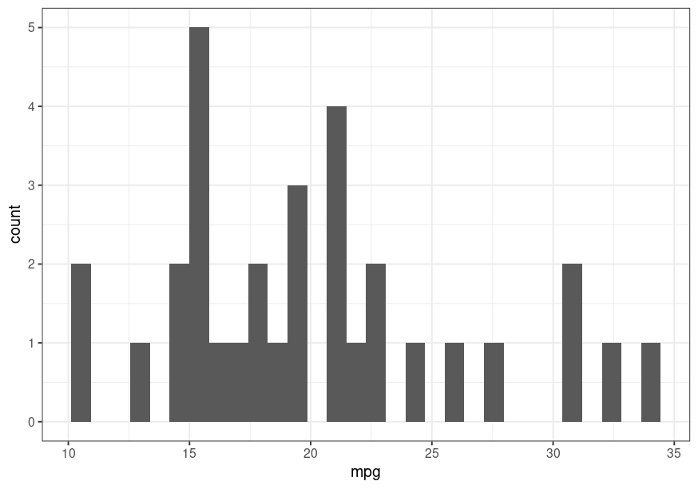

```r
ggplot(data = mtcars, aes(x = mpg)) + geom_histogram()
```

```r
ggsave(file = "mygraph.pdf")
```

##### Common Mistakes

After working with `ggplot2` for years,

- I’ve found that there are two mistakes that are frequently made.
- The first is omitting or misplacing a closing parentheses.
  - This happens most often following the aes() function.

Consider the following code.

```
ggplot(CPS85, aes(x = exper, y = wage, color = sex) +
         geom_point()
```

- Note the lack of a closing parentheses at the end of the first line.
  - I can’t tell you how many times I’ve done this.

The second error is confusing an assignment for a mapping.

This code produces the next graph.

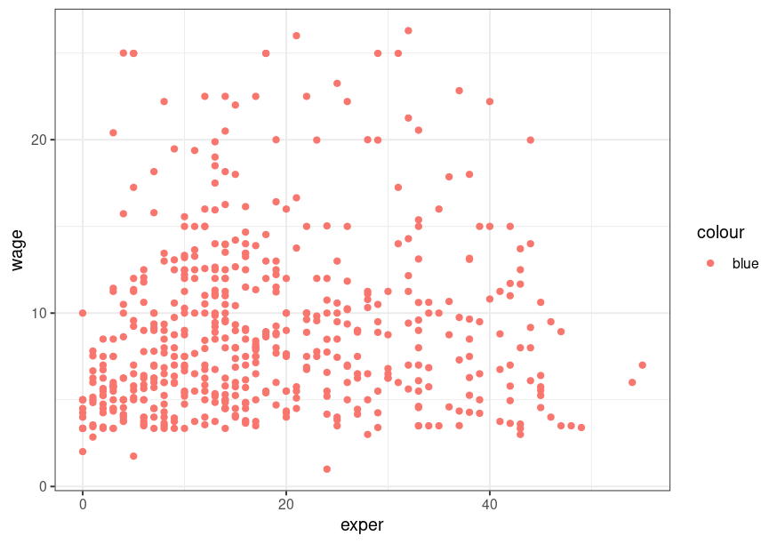

```r
ggplot(CPS85, aes(x = exper, y = wage, color = "blue")) +
  geom_point()
```

The points are red (not blue) and there is a strange legend.

- What happened?

The `aes()` function is used

- to map variables to the visual characteristics of the graph.
- Assigning constant values is done outside the `aes()` function.

#### `ggplot2` Summary

- The `ggplot2` package provides a powerful platform
  - for creating both simple and complex graphs.
  - Graphs are built up in layers
    - using functions chained together with the plus (`+`) symbol.
- The `ggplot()` function specifies a data frame
  - containing plot data
  - and an `aes()` function that maps variables
    - to visual aspects of the graph.
  - `geom_` functions specify the geometric objects
    - (bars, lines, points, etc.)
    - to be placed on the graph.
- Optional `scale_` functions allow you to
  - customize how a variable’s values
    - will be translated into their visual representations on the graph
    - (e.g., the x- and y-axis scales and labels to used,
    - and what colors, shapes, and line-types
    - will be mapped to a variable’s values).
- Data from two or more groups
  - can be represented by grouping
  - (superimposing plots distinguished by visual aspects such as color)
  - or faceting (placing several small plots in a matrix-like array).
- Two common errors of ggplot are
  - missing/misplaced parentheses
  - nd confusing an assignment for a mapping.
- Graphs can be exported in a wide variety of image formats
  - (such as tiff, pdf, jpg, png, svg, and wmf)
  - using the RStudio GUI
  - or with the `ggsave()` function.

#### Links

- Robert I. Kabacoff, R in Action, 3rd Edition, Manning Publications 2020